# Brief visualisation of the variance heuristic

Athénaïs Gautier

Last revised - January 2025

# SLGP modelling

The SLGP model, related to Tokdar, Zhu, and Ghosh (2010) and being at the center of the present contribution following up on Gautier, Ginsbourger, and Pirot (2021), Gautier and Ginsbourger (2021), Gautier (2023), is itself a spatial generalization of the Logistic Gaussian Process models, which were established and studied in Lenk (1988), Lenk (1991), Leonard (1978).

The SLGP for spatially dependent density estimation builds upon a well-behaved GP $(Z_{\mathbf{x}, t})_{(\mathbf{x}, t) \in D\times\mathcal{T}}$ and studies the stochastic process obtained from applying the spatial logistic density transformation to $Z$ as follows:

$$\label{eq:informalSLGP}
\Psi[Z](\mathbf{x}, t)= \dfrac{e^{\sigma Z_{\mathbf{x}, t}}}{\int_{[0,
1]} e^{\sigma Z_{\mathbf{x}, u}} \,d\lambda(u) } \text{ for all }
(\mathbf{x}, t) \in D\times\mathcal{T}$$
At any fixed $\mathbf{x}$, $\Psi[Z](\mathbf{x}, \cdot)$ hence returns a random function that is, by construction, positive and integrates to one, therefore, a SLGP can be (informally) seen as a field of random pdfs. Also note that $\sigma^2$ is a variance parameter that needs to be selected.

# Selecting the variance

To select $\sigma^2$, we use a heuristic ensuring that:
$$\mathbb{E}[\max_{\mathbf{x}\in D} \vert \max_{t
\in \mathcal{T}} \sigma Z_{\mathbf{x}, t} - \min_{t \in \mathcal{T}}
\sigma Z_{\mathbf{x}, t}\vert ] \leq 5$$
i.e.

$$\sigma \leq
\frac{5}{\mathbb{E}[\max_{\mathbf{x}\in D} \vert \max_{t \in
\mathcal{T}} Z_{\mathbf{x}, t} - \min_{t \in
\mathcal{T}} Z_{\mathbf{x}, t}\vert ]}$$

This heuristic controls the range of values that the SLGP can take, typically restricting it to $[0, e^5\approx 148]$.

# Qualitative Analysis of the SLGP Range

To justify this choice, we offer a qualitative analysis by drawing GP realizations and observing the corresponding SLGPs with varying values of the GP’s range defined as $\max_{\mathbf{x}\in D} \vert \max_{t \in \mathcal{T}} Z_{\mathbf{x}, t} - \min_{t \in \mathcal{T}} Z_{\mathbf{x}, t}\vert$. We illustrate this with several simulations.

```r
library(MASS)

# Define a 2D grid
x <- seq(0, 1, length.out = 51)
t <- seq(0, 1, length.out = 51)
grid <- expand.grid(x = x, t = t)

# Exponential kernel covariance function
exp_cov <- function(x1, x2, var = 1, scale = 0.1) {
  dist_matrix <- as.matrix(dist(rbind(x1, x2), method = "euclidean"))[1:nrow(x1), (nrow(x1) + 1):(nrow(x1) + nrow(x2))]
  var * exp(-dist_matrix / scale)
}

# Gaussian kernel covariance function
gauss_cov <- function(x1, x2, var = 1, scale = 0.1) {
  dist_matrix <- as.matrix(dist(rbind(x1, x2), method = "euclidean"))[1:nrow(x1), (nrow(x1) + 1):(nrow(x1) + nrow(x2))]
  var * exp(-dist_matrix^2 / (2 * scale^2))
}

# Compute covariance matrices
cov_matrix_exp <- exp_cov(grid, grid)
cov_matrix_gauss <- gauss_cov(grid, grid)

set.seed(0)

# Draw samples from multivariate normal distribution
field_exp <- mvrnorm(n = 2, mu = rep(0, nrow(grid)), Sigma = cov_matrix_exp)
field_gauss <- mvrnorm(n = 2, mu = rep(0, nrow(grid)), Sigma = cov_matrix_gauss)

dfplot <- data.frame(rbind(grid, grid, grid, grid))
dfplot$value <- c(field_exp[1, ], field_exp[2, ],
                  field_gauss[1, ], field_gauss[2, ])
dfplot$name <- c(sapply(seq(4), function(x){rep(paste0("GP", x), nrow(grid))}))

library(dplyr)
# Controle the range
dfplot <- dfplot %>%
  group_by(name, x) %>%
  mutate(range = max(value)-min(value))%>%
  ungroup()%>%
  group_by(name) %>%
  mutate(range = max(range))%>%
  ungroup()%>%
  mutate(value=value/range)%>%
  dplyr::select(-range)
```

In these simulations, we generate 4 realisations of GPs with two levels of smoothness, ensuring that the range $\max_{\mathbf{x}\in D} \vert \max_{t \in \mathcal{T}} Z_{\mathbf{x}, t} - \min_{t \in \mathcal{T}} Z_{\mathbf{x}, t}\vert \approx 1$. Below is a visual representation of these GPs.

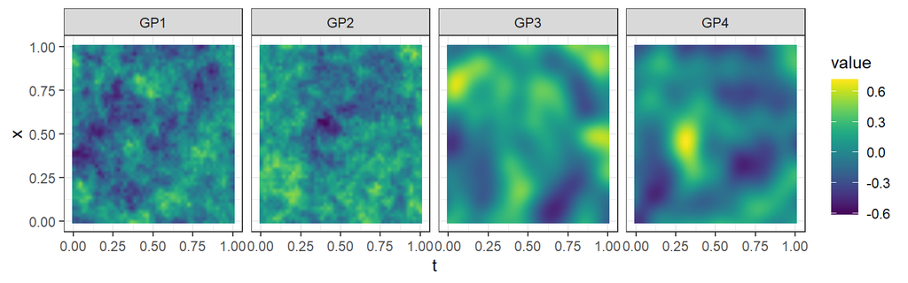

GP realisations considered

We can also consider SLGPs for these GPs and various valyes of $\sigma$ to demonstrate its effect on the model’s flexibility.

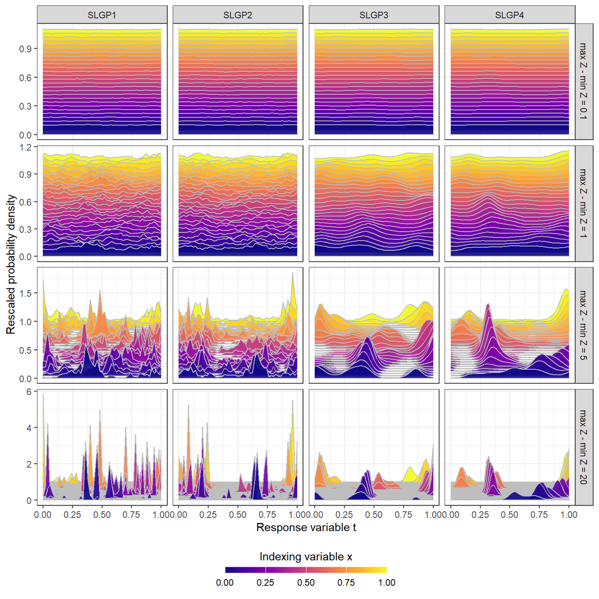

Associated SLGP realisations for varying ranges

These numerical experiment illustrate the influence of $\sigma$ on the SLGP’s expressiveness:

- *Low Range (e.g., 0.1):*, SLGPs resemble fields of uniform distributions, showing limited flexibility.
- *Moderate Range (e.g., 5):* exhibit better flexibility, place probability mass across the entire interval $[0, 1]$, while differing sufficiently from the uniform distribution to approximate a broad spectrum of densities.
- *Higher Range (e.g., 20):* SLGPs become overly “peaked”, assigning probability mass to small regions and making the model highly sensitive to GP variations, which complicates inference

Based on these observations, we have implemented SLGPs to maintain moderate ranges by choosing $\sigma$ a priori (i.e. without data infering in this choice) to achieve an approximate GP range of 5, balancing flexibility and stability.

## References

Gautier, Athénaïs. 2023. “Modelling and Predicting Distribution-Valued Fields with Applications to Inversion Under Uncertainty.” {PhD} {Thesis}, Institute of Mathematical Statistics; Actuarial Science, University of Bern.

Gautier, Athénaïs, and David Ginsbourger. 2021. “Continuous Logistic Gaussian Random Measure Fields for Spatial Distributional Modelling.”

Gautier, Athénaïs, David Ginsbourger, and Guillaume Pirot. 2021. “Goal-Oriented Adaptive Sampling Under Random Field Modelling of Response Probability Distributions.” *ESAIM: Proceedings and Surveys* 71: 89–100. https://doi.org/10.1051/proc/202171108.

Lenk, Peter J. 1988. “The Logistic Normal Distribution for Bayesian, Nonparametric, Predictive Densities.” *Journal of the American Statistical Association* 83 (402): 509–16.

———. 1991. “Towards a Practicable Bayesian Nonparametric Density Estimator.” *Biometrika* 78 (3): 531–43.

Leonard, Tom. 1978. “Density Estimation, Stochastic Processes and Prior Information.” *Journal of the Royal Statistical Society, Series B: Methodological* 40 (2): 113–32.

Tokdar, Surya T., Yu M. Zhu, and Jayanta K. Ghosh. 2010. “Bayesian Density Regression with Logistic Gaussian Process and Subspace Projection.” *Bayesian Analysis* 5 (2): 319–44.